# Integrated Probabilistic Assessment for Ethylene Oxide

Ann Roseberry Lincoln, Chris Kirman, Ron Kotun, Theresa Lopez

06 May 2020

# 1 Integrated Probabilistic Treatment of Toxicity Data (Chris Kirman)

## 1.1 Probabilistic Treatment of EO Unit Risk Based on Animal Data

### 1.1.1 Screening-Level Characterization of Uncertainty of Animal-Based Potency Estimates

#### 1.1.1.1 Single tumor site: Lung tumors in female mice

For the first example, a screening-level distribution is developed for ethylene oxide (EO) based on lung tumors in female mice. From the three datapoints for the Point of Departure (POD; min=LEC10, max=UEC10, best=EC10), a triangular distribution can be generated. These three values represent the 5th percentile, 95th percentile, and 50th percentile.

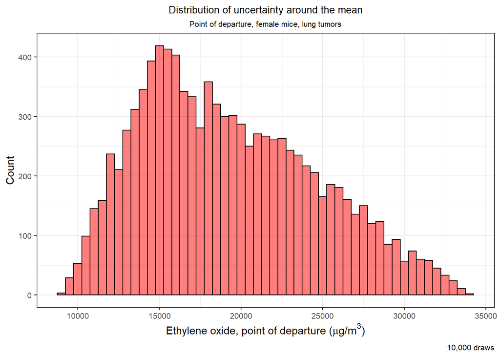

```r
pod.fm.lung <- EnvStats::rtri(numsamps, 9100, 34000, 14800)
pod.fm.lung <- as.data.frame(pod.fm.lung)
colnames(pod.fm.lung)[1] <- "EC.fm.lung"
ggplot2::ggplot(pod.fm.lung, ggplot2::aes(EC.fm.lung)) +
    ggplot2::geom_histogram(binwidth=500, color="black", fill="red"
                            , alpha=0.5) +
    ggplot2::theme_bw() +
    ggplot2::labs(title="Distribution of uncertainty around the mean"
                  , subtitle = "Point of departure, female mice, lung tumors"
                  , caption = "10,000 draws"
                  , x = xlabel_pod
                  , y = "Count") +
    ggplot2::theme(plot.title = ggplot2::element_text(hjust=0.5, size=10)
                   , plot.subtitle = ggplot2::element_text(hjust=0.5, size=8)
                   , axis.text = ggplot2::element_text(size=8)
                   , plot.caption = ggplot2::element_text(size=8))
```

Unit risk can be calculated by dividing the benchmark response rate by the POD value:

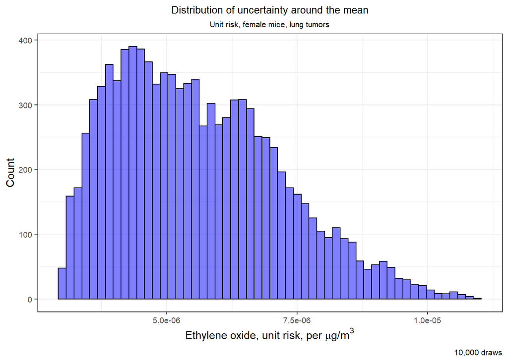

```r
BMR <- 0.1
ur.fm.lung <- BMR / pod.fm.lung$EC.fm.lung
ur.fm.lung <- as.data.frame(ur.fm.lung)
colnames(ur.fm.lung)[1] <- "ur.fm.lung"
ggplot2::ggplot(ur.fm.lung, ggplot2::aes(ur.fm.lung)) +
    ggplot2::geom_histogram(binwidth=0.00000015,color="black",fill="blue"
                            ,alpha=0.5) +
    ggplot2::theme_bw() +
    ggplot2::labs(title="Distribution of uncertainty around the mean"
                  , subtitle = "Unit risk, female mice, lung tumors"
                  , caption = "10,000 draws"
                  , x = xlabel_ur
                  , y = "Count") +
    ggplot2::theme(plot.title = ggplot2::element_text(hjust=0.5, size=10)
                   , plot.subtitle = ggplot2::element_text(hjust=0.5, size=8)
                   , axis.text = ggplot2::element_text(size=8)
                   , plot.caption = ggplot2::element_text(size=8))
```

To be more inclusive of the tails of the distribution, the 1st, 50th, and 99th percentiles can be used, as shown below.

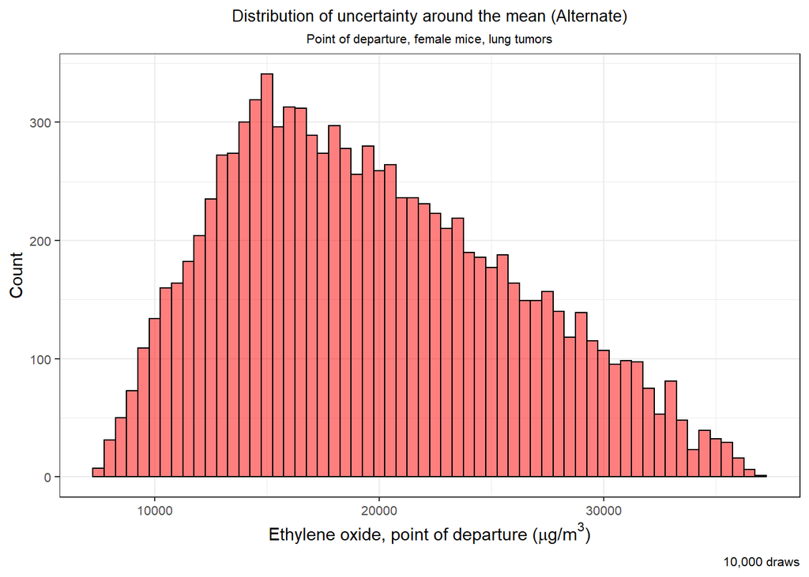

```r
pod.fm.lung.alt <- EnvStats::rtri(numsamps, 7300, 37000, 14800)
pod.fm.lung.alt <- as.data.frame(pod.fm.lung.alt)
colnames(pod.fm.lung.alt)[1] <- "EC.fm.lung.alt"
ggplot2::ggplot(pod.fm.lung.alt, ggplot2::aes(EC.fm.lung.alt)) +
    ggplot2::geom_histogram(binwidth=500, color="black", fill="red", alpha=0.5) +
    ggplot2::theme_bw() +
    ggplot2::labs(title="Distribution of uncertainty around the mean (Alternate)"
                  , subtitle = "Point of departure, female mice, lung tumors"
                  , caption = "10,000 draws"
                  , x = xlabel_pod
                  , y = "Count") +
    ggplot2::theme(plot.title = ggplot2::element_text(hjust=0.5, size=10)
                   , plot.subtitle = ggplot2::element_text(hjust=0.5, size=8)
                   , axis.text = ggplot2::element_text(size=8)
                   , plot.caption = ggplot2::element_text(size=8))
```

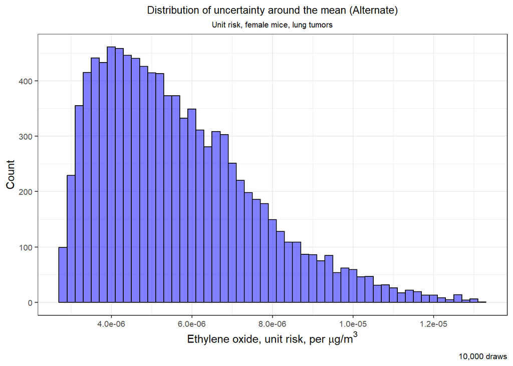

```r
ur.fm.lung.alt <- BMR / pod.fm.lung.alt$EC.fm.lung.alt
ur.fm.lung.alt <- as.data.frame(ur.fm.lung.alt)
colnames(ur.fm.lung.alt)[1] <- "ur.fm.lung.alt"
ggplot2::ggplot(ur.fm.lung.alt, ggplot2::aes(ur.fm.lung.alt)) +
    ggplot2::geom_histogram(binwidth=0.0000002,color="black",fill="blue",alpha=0.5) +
    ggplot2::theme_bw() +
    ggplot2::labs(title="Distribution of uncertainty around the mean (Alternate)"
                  , subtitle = "Unit risk, female mice, lung tumors"
                  , caption = "10,000 draws"
                  , x = xlabel_ur
                  , y = "Count") +
    ggplot2::theme(plot.title = ggplot2::element_text(hjust=0.5, size=10)
                   , plot.subtitle = ggplot2::element_text(hjust=0.5, size=8)
                   , axis.text = ggplot2::element_text(size=8)
                   , plot.caption = ggplot2::element_text(size=8))
```

#### 1.1.1.2 Combining Unit Risks across tumor sites: All tumors in female mice

These steps are repeated for data representing lymphoma, uterine, and mammary tumors in female mice. The unit risk for combined tumor types can be estimated by assuming the risks are independent and additive. Note that this approach assumes the tumors are mutually exclusive and does not account for the joint probability of different tumor types occurring in the same animal.

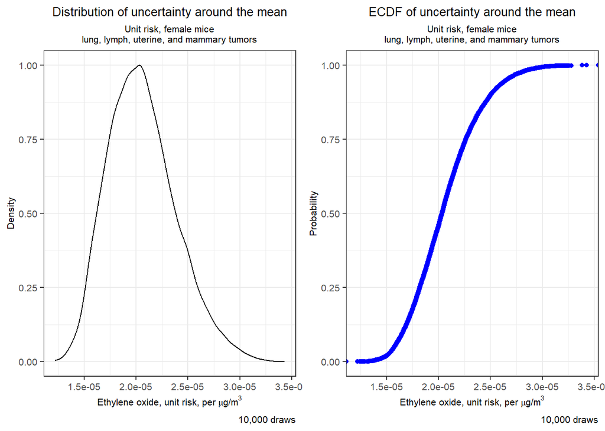

```r
# Lung tumors
pod.fm.lung <- EnvStats::rtri(numsamps, 9100, 34000, 14800)
pod.fm.lung <- as.data.frame(pod.fm.lung)
colnames(pod.fm.lung)[1] <- "EC"
ur.fm.lung <- BMR / pod.fm.lung$EC

# Lymphomas
pod.fm.lymph <- EnvStats::rtri(numsamps, 13900, 48500, 21100)
pod.fm.lymph <- as.data.frame(pod.fm.lymph)
colnames(pod.fm.lymph)[1] <- "EC"
ur.fm.lymph <- BMR / pod.fm.lymph$EC

# Uterine tumors
pod.fm.uter <- EnvStats::rtri(numsamps, 23100, 75400, 32800)
pod.fm.uter <- as.data.frame(pod.fm.uter)
colnames(pod.fm.uter)[1] <- "EC"
ur.fm.uter <- BMR / pod.fm.uter$EC

# Mammary tumors
pod.fm.mamm <- EnvStats::rtri (numsamps, 5350, 22300, 9690)
pod.fm.mamm <- as.data.frame(pod.fm.mamm)
colnames(pod.fm.mamm)[1] <- "EC"
ur.fm.mamm <- BMR / pod.fm.mamm$EC

# All tumors combined
ur.fm.comb <- ur.fm.lung + ur.fm.lymph + ur.fm.uter + ur.fm.mamm
ur.fm.comb <- as.data.frame(ur.fm.comb)
colnames(ur.fm.comb)[1] <- "UnitRisk"

pdf <- ggplot2::ggplot(ur.fm.comb, ggplot2::aes(UnitRisk)) +
    ggplot2::geom_density(ggplot2::aes(y=ggplot2::after_stat(count/max(count)))) +
    ggplot2::theme_bw() +
    ggplot2::labs(title="Distribution of uncertainty around the mean"
                  , subtitle = paste("Unit risk, female mice"
                        , "lung, lymph, uterine, and mammary tumors"
                        , sep = "\n")
                  , caption = "10,000 draws"
                  , x = xlabel_ur
                  , y = "Density") +
    ggplot2::theme(plot.title = ggplot2::element_text(hjust=0.5, size=10)
                   , plot.subtitle = ggplot2::element_text(hjust=0.5, size=8)
                   , axis.text = ggplot2::element_text(size=8)
                   , axis.title = ggplot2::element_text(size=8)
                   , plot.caption = ggplot2::element_text(size=8))

cdf <- ggplot2::ggplot(ur.fm.comb, ggplot2::aes(UnitRisk)) +
    ggplot2::stat_ecdf(geom = "point", color = "blue") +
    ggplot2::theme_bw() +
    ggplot2::labs(title="ECDF of uncertainty around the mean"
                  , subtitle = paste("Unit risk, female mice"
                        , "lung, lymph, uterine, and mammary tumors"
                        , sep = "\n")
                  , caption = "10,000 draws"
                  , x = xlabel_ur
                  , y = "Probability") +
    ggplot2::theme(plot.title = ggplot2::element_text(hjust=0.5, size=10)
                   , plot.subtitle = ggplot2::element_text(hjust=0.5, size=8)
                   , axis.text = ggplot2::element_text(size=8)
                   , axis.title = ggplot2::element_text(size=8)
                   , plot.caption = ggplot2::element_text(size=8))

gridExtra::grid.arrange(pdf, cdf, nrow=1, ncol=2)
```

```r
meanCombIUR <- mean(ur.fm.comb$UnitRisk)
medCombIUR <- median(ur.fm.comb$UnitRisk)
```

#### 1.1.1.3 Combining Unit Risks across data sets: Species and sex

To include data from multiple data sets, repeat the steps above to develop corresponding Unit Risk values for each of the remaining data sets. In this case, male mice, female rats, and male rats.

**Note:** Based on a conversation with Chris Kirman (2020-05-20), the ur.all.rodents should be represented by a random sampling of 4 distributions, each with a 25% probability of being sampled. Unless the group feels strongly that we should demonstrate this, he recommends not developing the remaining distributions (male mice, female rats, and male rats).

### 1.1.2 Refined Characterization of Uncertainty for Animal-based Potency Estimates

Use BMDS output to generate an ECDF of the error around the POD based on data provided by the BMDS program. Chris’s explanation of this is clear. I have just provided code and graphics for the document.

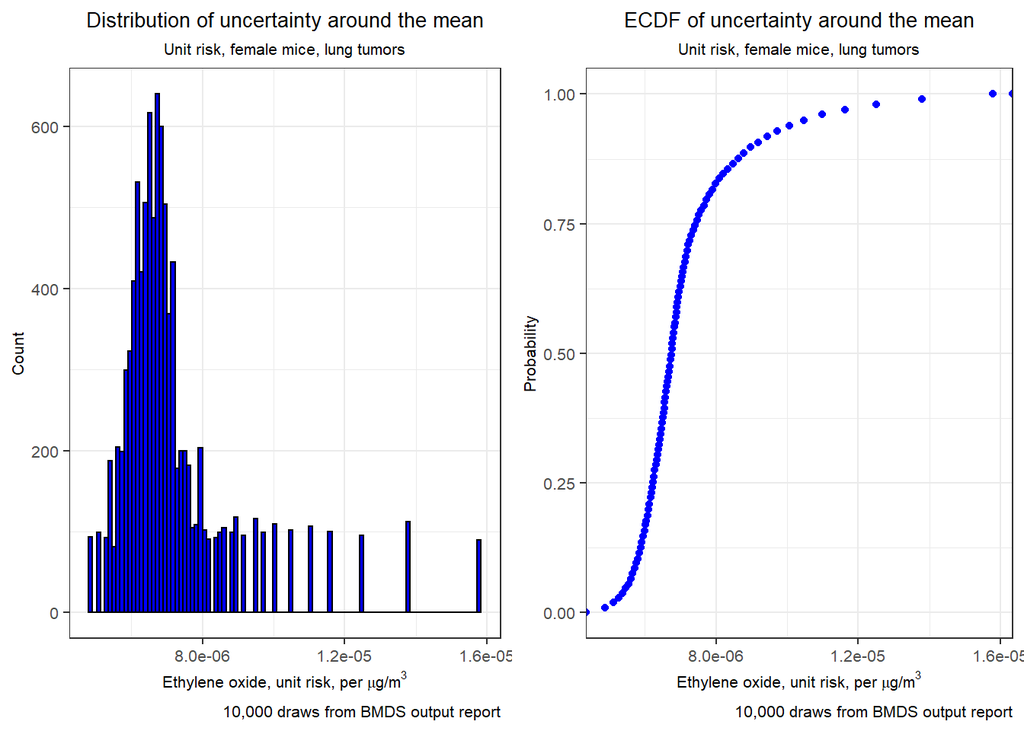

```r
wd <- getwd()
fn <- file.path("..","Data","BenchmarkDoseModel_m3_ug"
                ,"PODS.csv")
df_pods2 <- read.csv(fn, header=TRUE, na.strings=c("","NA")
                       , stringsAsFactors=FALSE)
df_urs2 <- BMR/df_pods2
ur.fm.lung2 <- sample(df_urs2$FM.Lung, size=numsamps, replace=TRUE)
df_ur.fm.lung2 <- data.frame("FM.Lung" = ur.fm.lung2)

pdf2 <- ggplot2::ggplot(df_ur.fm.lung2, ggplot2::aes(FM.Lung)) +
    ggplot2::geom_histogram(bins=100, color="black", fill="blue") +
    ggplot2::theme_bw() +
    ggplot2::labs(title="Distribution of uncertainty around the mean"
                  , subtitle = "Unit risk, female mice, lung tumors"
                  , caption = "10,000 draws from BMDS output report"
                  , x = xlabel_ur
                  , y = "Count") +
    ggplot2::theme(plot.title = ggplot2::element_text(hjust=0.5, size=10)
                   , plot.subtitle = ggplot2::element_text(hjust=0.5, size=8)
                   , axis.text = ggplot2::element_text(size=8)
                   , axis.title = ggplot2::element_text(size=8)
                   , plot.caption = ggplot2::element_text(size=8))

cdf2 <- ggplot2::ggplot(df_ur.fm.lung2, ggplot2::aes(FM.Lung)) +
    ggplot2::stat_ecdf(geom = "point", color = "blue") +
    ggplot2::theme_bw() +
    ggplot2::labs(title="ECDF of uncertainty around the mean"
                  , subtitle = "Unit risk, female mice, lung tumors"
                  , caption = "10,000 draws from BMDS output report"
                  , x = xlabel_ur
                  , y = "Probability") +
    ggplot2::theme(plot.title = ggplot2::element_text(hjust=0.5, size=10)
                   , plot.subtitle = ggplot2::element_text(hjust=0.5, size=8)
                   , axis.text = ggplot2::element_text(size=8)
                   , axis.title = ggplot2::element_text(size=8)
                   , plot.caption = ggplot2::element_text(size=8))

gridExtra::grid.arrange(pdf2, cdf2, nrow=1, ncol=2)
```

### 1.1.3 Refined Characterization of Uncertainty and Variation

Distribution derived by combining unit risks across tumor sites within a single species (p. 20 of July working draft).

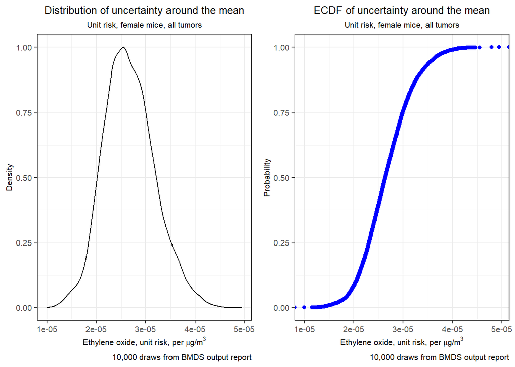

```r
ur.fm.lymph2 <- sample(df_urs2$FM.Lymph, size=numsamps, replace=TRUE)
ur.fm.uter2 <- sample(df_urs2$FM.Uterine, size=numsamps, replace=TRUE)
ur.fm.mam2 <- sample(df_urs2$FM.Mammary, size=numsamps, replace=TRUE)
ur.fm.comb2 <- ur.fm.lung2 + ur.fm.lymph2 + ur.fm.uter2 + ur.fm.mam2
ur.fm.comb2 <- data.frame("UnitRisk" = ur.fm.comb2)

pdf3 <- ggplot2::ggplot(ur.fm.comb2, ggplot2::aes(UnitRisk)) +
    ggplot2::geom_density(ggplot2::aes(y=ggplot2::after_stat(count/max(count)))) +
    ggplot2::theme_bw() +
    ggplot2::labs(title="Distribution of uncertainty around the mean"
                  , subtitle = "Unit risk, female mice, all tumors"
                  , caption = "10,000 draws from BMDS output report"
                  , x = xlabel_ur
                  , y = "Density") +
    ggplot2::theme(plot.title = ggplot2::element_text(hjust=0.5, size=10)
                   , plot.subtitle = ggplot2::element_text(hjust=0.5, size=8)
                   , axis.text = ggplot2::element_text(size=8)
                   , axis.title = ggplot2::element_text(size=8)
                   , plot.caption = ggplot2::element_text(size=8))

cdf3 <- ggplot2::ggplot(ur.fm.comb2, ggplot2::aes(UnitRisk)) +
    ggplot2::stat_ecdf(geom = "point", color = "blue") +
    ggplot2::theme_bw() +
    ggplot2::labs(title="ECDF of uncertainty around the mean"
                  , subtitle = "Unit risk, female mice, all tumors"
                  , caption = "10,000 draws from BMDS output report"
                  , x = xlabel_ur
                  , y = "Probability") +
    ggplot2::theme(plot.title = ggplot2::element_text(hjust=0.5, size=10)
                   , plot.subtitle = ggplot2::element_text(hjust=0.5, size=8)
                   , axis.text = ggplot2::element_text(size=8)
                   , axis.title = ggplot2::element_text(size=8)
                   , plot.caption = ggplot2::element_text(size=8))

gridExtra::grid.arrange(pdf3, cdf3, nrow=1, ncol=2)
```

```r
meanBMDS <- mean(ur.fm.comb2$UnitRisk, na.rm=TRUE)
medBMDS <- median(ur.fm.comb2$UnitRisk, na.rm = TRUE)
```

#### 1.1.3.1 Compare Mouse Screening/Refined IURs

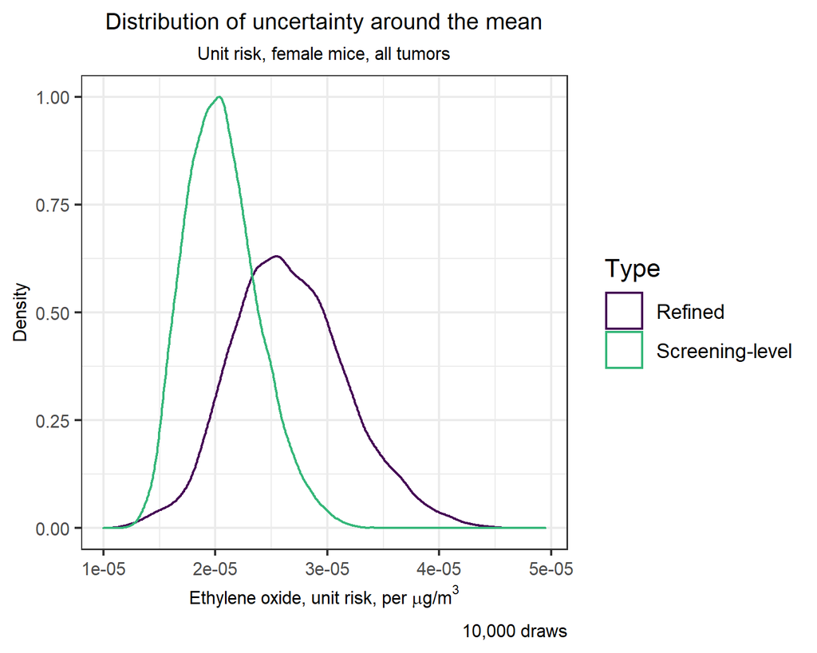

```r
ur.fm.comb$Type <- "Screening-level"
ur.fm.comb2$Type <- "Refined"
ur.fm.comb2 <- ur.fm.comb2[!is.na(ur.fm.comb2$UnitRisk),]
ur.fm.comb3 <- rbind(ur.fm.comb, ur.fm.comb2)

pal4 <- viridis::viridis(4)

pdf_mcomp <- ggplot2::ggplot(ur.fm.comb3
                    , ggplot2::aes(x=UnitRisk
                                   ,y=ggplot2::after_stat(count/max(count))
                    , color=Type)) +
    ggplot2::geom_density() +
    ggplot2::scale_color_manual(values=c(pal4[1], pal4[3])) +
    ggplot2::theme_bw() +
    ggplot2::labs(title="Distribution of uncertainty around the mean"
                  , subtitle = "Unit risk, female mice, all tumors"
                  , caption = "10,000 draws"
                  , x = xlabel_ur
                  , y = "Density") +
    ggplot2::theme(plot.title = ggplot2::element_text(hjust=0.5, size=10)
                   , plot.subtitle = ggplot2::element_text(hjust=0.5, size=8)
                   , axis.text = ggplot2::element_text(size=8)
                   , axis.title = ggplot2::element_text(size=8)
                   , plot.caption = ggplot2::element_text(size=8))
fn_mcomp <- file.path(outdir,"IUR_MouseScreenVRefined.png")
ggplot2::ggsave(fn_mcomp, pdf_mcomp,height=4, width=5, units="in", dpi=300)

knitr::include_graphics(path = fn_mcomp)
```

### 1.1.4 Additional Refinements

There’s a good bit of text here, but no code or graphics.

## 1.2 Characterization of Epidemiology-based Risk Values

### 1.2.1 Screening-level characterization of uncertainty

#### 1.2.1.1 Single cancer type: Lymphoid cancer in workers

Use a triangular distribution with min=LEC01, max=UEC01, best=EC01 to create POD distribution and multiply by a conversion factor (from ppm to $\mu$g/m<sup>3</sup>) of 1,802. UR, if used directly (i.e., not generated from the POD), will be divided by this conversion factor.

```r
CF_ppm_ugm3 <- 1802
# Generate EC ppm distribution (original--matches image in text currently)
pod.epi.lymph <- as.data.frame(EnvStats::rtri(numsamps, 0.00271, 0.147
                                               , 0.0107))
colnames(pod.epi.lymph)[1] <- "EC_ppm"

# Generate EC ug/m3 distribution by converting distribution (use this one)
pod.epi.lymph.ugm3 <- as.data.frame(EnvStats::rtri(numsamps, 0.00271, 0.147,
                                               0.0107)*CF_ppm_ugm3)
colnames(pod.epi.lymph.ugm3)[1] <- "EC_ug_m3"

BMRepi <- 0.01
ur.epi.lymph.perugm3 <- dplyr::mutate(pod.epi.lymph.ugm3
                              , UnitRisk = eval(BMRepi) / EC_ug_m3)

pdf_ur.epi.lymph <- ggplot2::ggplot(ur.epi.lymph.perugm3
                                , ggplot2::aes(UnitRisk)) +
    ggplot2::geom_histogram(binwidth=0.00002, color="black", fill="blue"
                            , alpha=0.5) +
    ggplot2::theme_bw() +
    ggplot2::labs(title="Distribution of uncertainty around the mean"
                  , subtitle = "Lymphoid cancers in workers"
                  , caption = "10,000 draws"
                  , x=xlabel_ur
                  , y = "Count") +
    ggplot2::theme(plot.title = ggplot2::element_text(hjust=0.5, size=10)
                   , plot.subtitle = ggplot2::element_text(hjust=0.5, size=8)
                   , axis.text = ggplot2::element_text(size=8)
                   , axis.title = ggplot2::element_text(size=8)
                   , plot.caption = ggplot2::element_text(size=8))
```

#### 1.2.1.2 Combining Unit Risks across cancer types

This first example cites personal communication with Dr. Valdez-Flores. (Figure 9 in the June text–ur.epi.lymph1)

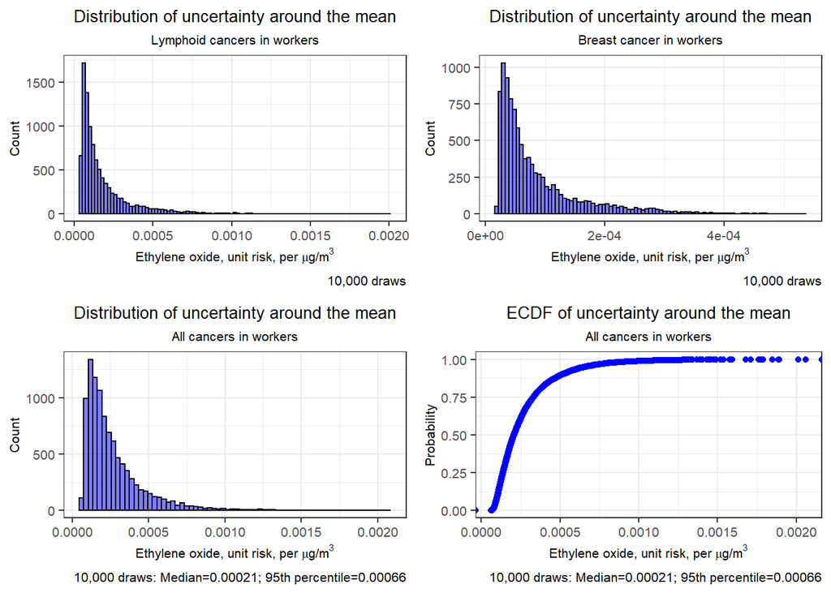

```r
# Breast cancers
pod.epi.breast.ugm3 <- as.data.frame(EnvStats::rtri(numsamps, 0.0101, 0.284
                                               , 0.0206)*CF_ppm_ugm3)
colnames(pod.epi.breast.ugm3)[1] <- "EC"
ur.epi.breast.perugm3 <- dplyr::mutate(pod.epi.breast.ugm3
                                       , UnitRisk = eval(BMRepi) / EC)
pdf_ur.epi.breast <- ggplot2::ggplot(ur.epi.breast.perugm3
                                , ggplot2::aes(UnitRisk)) +
    ggplot2::geom_histogram(binwidth=0.000006, color="black", fill="blue"
                            , alpha=0.5) +
    ggplot2::theme_bw() +
    ggplot2::labs(title="Distribution of uncertainty around the mean"
                  , subtitle = "Breast cancer in workers"
                  , caption = "10,000 draws"
                  , x=xlabel_ur
                  , y = "Count") +
    ggplot2::theme(plot.title = ggplot2::element_text(hjust=0.5, size=10)
                   , plot.subtitle = ggplot2::element_text(hjust=0.5, size=8)
                   , axis.text = ggplot2::element_text(size=8)
                   , axis.title = ggplot2::element_text(size=8)
                   , plot.caption = ggplot2::element_text(size=8))

# Combined cancers
ur.epi.comb.perugm3 <- as.data.frame(ur.epi.lymph.perugm3$UnitRisk + ur.epi.breast.perugm3$UnitRisk)
colnames(ur.epi.comb.perugm3)[1] <- "UnitRisk"

median.epi.comb <- quantile(ur.epi.comb.perugm3$UnitRisk, probs=0.50)
ucl.epi.comb <- quantile(ur.epi.comb.perugm3$UnitRisk, probs=0.95)
epi_caption <- paste0("10,000 draws: Median=", round(median.epi.comb,5)
                   , "; 95th percentile=", round(ucl.epi.comb,5))

pdf_ur.epi.comb <- ggplot2::ggplot(ur.epi.comb.perugm3
                                   , ggplot2::aes(UnitRisk)) +
    ggplot2::geom_histogram(binwidth=0.00003, color="black", fill="blue"
                            , alpha=0.5) +
    ggplot2::theme_bw() +
    ggplot2::labs(title="Distribution of uncertainty around the mean"
                  , subtitle = "All cancers in workers"
                  , caption = epi_caption
                  , x=xlabel_ur
                  , y = "Count") +
    ggplot2::theme(plot.title = ggplot2::element_text(hjust=0.5, size=10)
                   , plot.subtitle = ggplot2::element_text(hjust=0.5, size=8)
                   , axis.text = ggplot2::element_text(size=8)
                   , axis.title = ggplot2::element_text(size=8)
                   , plot.caption = ggplot2::element_text(size=8))

cdf_ur.epi.comb <- ggplot2::ggplot(ur.epi.comb.perugm3
                                   , ggplot2::aes(UnitRisk)) +
    ggplot2::stat_ecdf(geom = "point", color = "blue") +
    ggplot2::theme_bw() +
    ggplot2::labs(title="ECDF of uncertainty around the mean"
                  , subtitle = "All cancers in workers"
                  , caption = epi_caption
                  , x = xlabel_ur
                  , y = "Probability") +
    ggplot2::theme(plot.title = ggplot2::element_text(hjust=0.5, size=10)
                   , plot.subtitle = ggplot2::element_text(hjust=0.5, size=8)
                   , axis.text = ggplot2::element_text(size=8)
                   , axis.title = ggplot2::element_text(size=8)
                   , plot.caption = ggplot2::element_text(size=8))

gridExtra::grid.arrange(pdf_ur.epi.lymph, pdf_ur.epi.breast, pdf_ur.epi.comb
                        , cdf_ur.epi.comb, nrow = 2, ncol = 2)
```

### 1.2.2 Refined Characterization of Uncertainty

#### 1.2.2.1 Single cancer type: Lymphoid cancer in workers

This section presents similar data, but normal distributions

```r
# Lymphoid cancers -- Line 1 Table 4-17 (EPA citation)
set.seed(123)
ur.epi.lymph.adults <- as.data.frame(rnorm(numsamps, 1.34, 2.38)/CF_ppm_ugm3)
colnames(ur.epi.lymph.adults)[1] <- "UnitRisk"

pdf_epi.lymph.adults <- ggplot2::ggplot(ur.epi.lymph.adults
                                        , ggplot2::aes(UnitRisk)) +
    ggplot2::geom_histogram(binwidth=0.0001, color="black", fill="blue") +
    ggplot2::theme_bw() +
    ggplot2::labs(title="Distribution of uncertainty around the mean"
                  , subtitle = "Lymphoid cancers in workers"
                  , caption = "10,000 draws"
                  , x=xlabel_ur
                  , y = "Count") +
    ggplot2::theme(plot.title = ggplot2::element_text(hjust=0.5, size=10)
                   , plot.subtitle = ggplot2::element_text(hjust=0.5, size=8)
                   , axis.text = ggplot2::element_text(size=10)
                   , plot.caption = ggplot2::element_text(size=8))

# Breast cancers -- Line 2 Table 4-17 (EPA citation)
set.seed(123)
ur.epi.breast.adults <- as.data.frame(rnorm(numsamps
                                            , 0.725, 0.459)/CF_ppm_ugm3)
colnames(ur.epi.breast.adults)[1] <- "UnitRisk"

pdf_epi.breast.adults <- ggplot2::ggplot(ur.epi.breast.adults
                                        , ggplot2::aes(UnitRisk)) +
    ggplot2::geom_histogram(binwidth=0.00002, color="black", fill="blue") +
    ggplot2::theme_bw() +
    ggplot2::labs(title="Distribution of uncertainty around the mean"
                  , subtitle = "Breast cancer in workers"
                  , caption = "10,000 draws"
                  , x=xlabel_ur
                  , y = "Count") +
    ggplot2::theme(plot.title = ggplot2::element_text(hjust=0.5, size=10)
                   , plot.subtitle = ggplot2::element_text(hjust=0.5, size=8)
                   , axis.text = ggplot2::element_text(size=10)
                   , plot.caption = ggplot2::element_text(size=8))
```

#### 1.2.2.2 Combining unit risks across cancer types

**DO NOT USE THIS FIRST FIGURE–IT WAS FOR DISCUSSION WITH CHRIS**

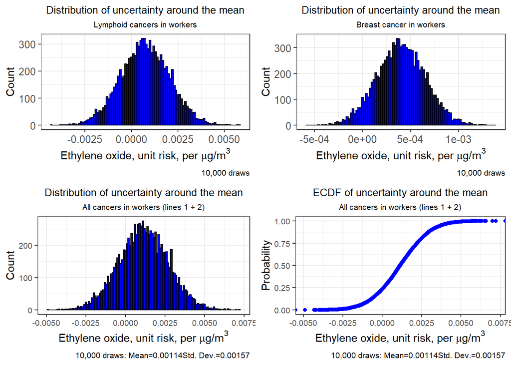

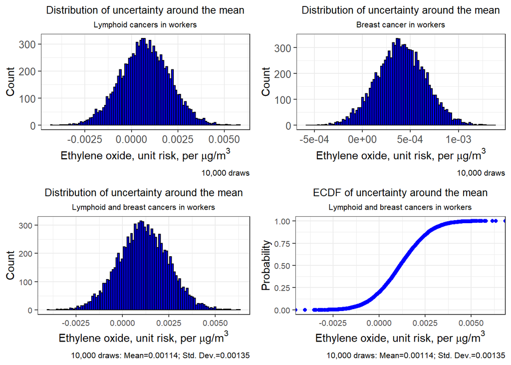

```r
# Comined cancers -- Preferred method (use line 3 Table 4-17 USEPA citation)
set.seed(123)
ur.epi.comb.adultsFINAL <- as.data.frame(rnorm(numsamps, 2.06, 2.43)/CF_ppm_ugm3)
colnames(ur.epi.comb.adultsFINAL)[1] <- "UnitRisk"

meanIURfinal <- mean(ur.epi.comb.adultsFINAL$UnitRisk)
sdIURfinal <- sd(ur.epi.comb.adultsFINAL$UnitRisk)
medianIURfinal <- quantile(ur.epi.comb.adultsFINAL$UnitRisk, probs = 0.50)
uclIURfinal <- quantile(ur.epi.comb.adultsFINAL$UnitRisk
                      , probs = c(0.90, 0.95, 0.99))
captionFINAL <- paste0("10,000 draws: Mean="
                     , format(meanIURfinal,digits=3,nsmall=0)
                     , "; Std. Dev.="
                     , format(sdIURfinal,digits=3,nsmall=0))
captionFINAL2 <- paste0("10,000 draws: Median="
                     , format(medianIURfinal,digits=3,nsmall=0)
                     , "; 95th percentile="
                     , format(uclIURfinal[2],digits=3,nsmall=0))

pdf_epi.comb.adults <- ggplot2::ggplot(ur.epi.comb.adultsFINAL
                                       , ggplot2::aes(UnitRisk)) +
    ggplot2::geom_histogram(binwidth=0.0001, color="black", fill="blue") +
    ggplot2::theme_bw() +
    ggplot2::labs(title="Distribution of uncertainty around the mean"
                  , subtitle = "Lymphoid and breast cancers in workers"
                  , caption = captionFINAL
                  , x = xlabel_ur
                  , y = "Count") +
    ggplot2::theme(plot.title = ggplot2::element_text(hjust=0.5, size=10)
                   , plot.subtitle = ggplot2::element_text(hjust=0.5, size=8)
                   , axis.text = ggplot2::element_text(size=8)
                   , plot.caption = ggplot2::element_text(size=8))

cdf_epi.comb.adults <- ggplot2::ggplot(ur.epi.comb.adultsFINAL
                                       , ggplot2::aes(UnitRisk)) +
    ggplot2::stat_ecdf(geom = "point", color = "blue") +
    ggplot2::theme_bw() +
    ggplot2::labs(title="ECDF of uncertainty around the mean"
                  , subtitle = "Lymphoid and breast cancers in workers"
                  , caption = captionFINAL
                  , x = xlabel_ur
                  , y = "Probability") +
    ggplot2::theme(plot.title = ggplot2::element_text(hjust=0.5, size=10)
                   , plot.subtitle = ggplot2::element_text(hjust=0.5, size=8)
                   , axis.text = ggplot2::element_text(size=8)
                   , plot.caption = ggplot2::element_text(size=8))

gridExtra::grid.arrange(pdf_epi.lymph.adults, pdf_epi.breast.adults
                        , pdf_epi.comb.adults, cdf_epi.comb.adults
                        , nrow=2, ncol=2)
```

```r
summaryStringFINAL <- paste0("Mean="
                     , format(meanIURfinal,digits=3,nsmall=0)
                     , "; Median="
                     , format(medianIURfinal,digits=3,nsmall=0)
                     , "; Std. Dev.="
                     , format(sdIURfinal,digits=3,nsmall=0)
                     , "; 95th %ile="
                     , format(uclIURfinal[2],digits=3,nsmall=0))
```

#### 1.2.2.3 Compare epidemiological screening and refined IURs

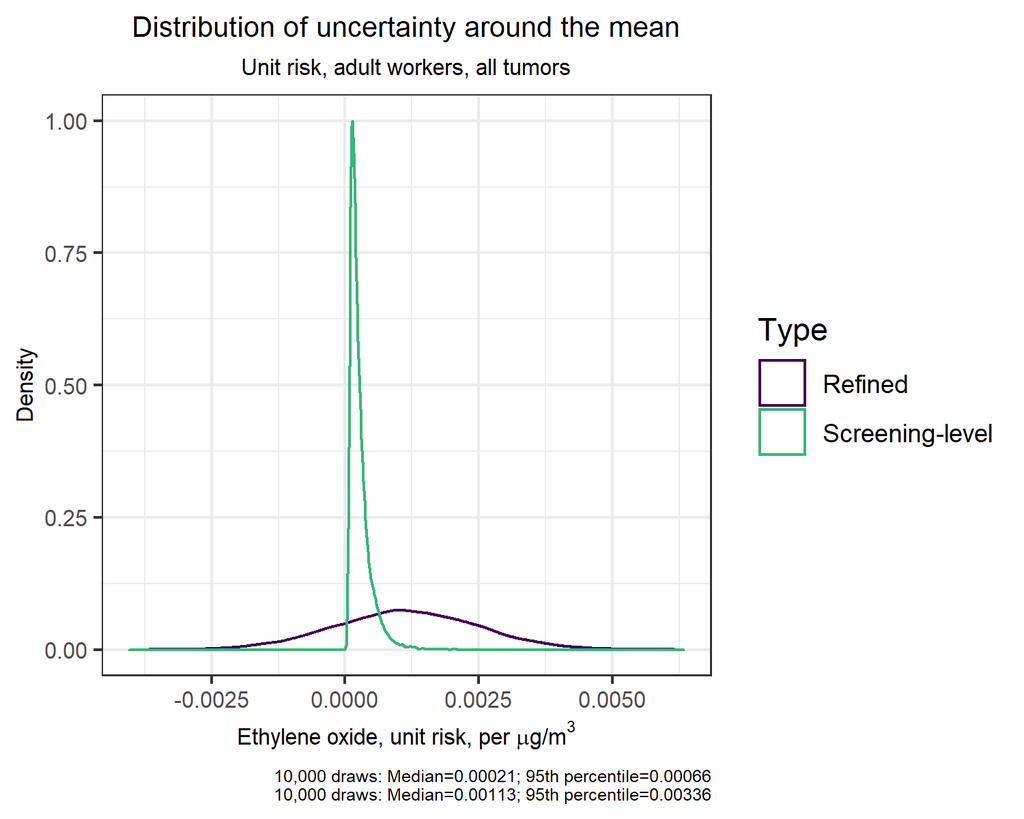

```r
ur.epi.comb.perugm3$Type <- "Screening-level"
ur.epi.comb.adultsFINAL$Type <- "Refined"
ur.epi.comb <- rbind(ur.epi.comb.perugm3, ur.epi.comb.adultsFINAL)

pdf_epicomp <- ggplot2::ggplot(ur.epi.comb
                    , ggplot2::aes(x=UnitRisk
                                   ,y=ggplot2::after_stat(count/max(count))
                    , color=Type)) +
    ggplot2::geom_density() +
    ggplot2::scale_color_manual(values=c(pal4[1], pal4[3])) +
    ggplot2::theme_bw() +
    ggplot2::labs(title="Distribution of uncertainty around the mean"
                  , subtitle = "Unit risk, adult workers, all tumors"
                  , caption = paste(epi_caption,captionFINAL2, sep="\n")
                  , x = xlabel_ur
                  , y = "Density") +
    ggplot2::theme(plot.title = ggplot2::element_text(hjust=0.5, size=10)
                   , plot.subtitle = ggplot2::element_text(hjust=0.5, size=8)
                   , axis.text = ggplot2::element_text(size=8)
                   , axis.title = ggplot2::element_text(size=8)
                   , plot.caption = ggplot2::element_text(size=6))
fn_epicomp <- file.path(outdir,"IUR_EpiScreenVRefined.png")
ggplot2::ggsave(fn_epicomp, pdf_epicomp, height=4, width=5, units="in", dpi=300)

knitr::include_graphics(path = fn_epicomp)
```

The distribution representing uncertainty in the unit risk point estimate is this last distribution: uncertainty about the mean that is normally distributed with a mean of 0.00114 and a standard deviation of 0.00135.

For Chris’s information: comparing sum of distributions with provided totals

Sum of lines 1 & 2 parameters: Mean=0.00114; Median=0.00113; Std. Dev.=0.00157; 95th %ile=0.00373  
Line 3 parameters: Mean=0.00114; Median=0.00113; Std. Dev.=0.00135; 95th %ile=0.00336  
Chris’s estimates:

- Central tendency = 0.0011 ($\mu$g/m<sup>3</sup>)<sup>-1</sup>
- UCL = 0.0033 ($\mu$g/m<sup>3</sup>)<sup>-1</sup>